# Carfilzomib_resistance

rbabaei

5/21/2020

## Introduction

The aquired resistance of multiple myeloma model cell lines (KMS11 and KMS34) to anti cancer agent Carfilzomib has been studied by Riz I et.al. The article has been published in Oncotarget (PMID: 26109433). The KMS11 and KMS34 cells have been cultured in the presence of Carfilzomib and their gene expression profiles have been compared to the parental cells. Here we will analyze the microarray data of this study, which is accessible on GEO data set under GDS5826.

## Data importing and tidying

The CEL format of data is downloaded from GEO. First we are going to load the data into console and modify some annotation according to our needs.

```r
celPath <- "D:/DataScience/Profile/MultipleMyeloma_GPL570/celFiles"

celList <- list.files(celPath, full.names = T)
celData <- read.celfiles(celList)
```

```
## Reading in : D:/DataScience/Profile/MultipleMyeloma_GPL570/celFiles/GSM1692587_EA13015_261900_HG-U133_PLUS_2_17.CEL
## Reading in : D:/DataScience/Profile/MultipleMyeloma_GPL570/celFiles/GSM1692588_EA13015_261899_HG-U133_PLUS_2_16.CEL
## Reading in : D:/DataScience/Profile/MultipleMyeloma_GPL570/celFiles/GSM1692589_EA13015_261901_HG-U133_PLUS_2_18.CEL
## Reading in : D:/DataScience/Profile/MultipleMyeloma_GPL570/celFiles/GSM1692590_EA13015_261893_HG-U133_PLUS_2_10.CEL
## Reading in : D:/DataScience/Profile/MultipleMyeloma_GPL570/celFiles/GSM1692591_EA13015_261894_HG-U133_PLUS_2_11.CEL
## Reading in : D:/DataScience/Profile/MultipleMyeloma_GPL570/celFiles/GSM1692592_EA13015_261895_HG-U133_PLUS_2_12.CEL
## Reading in : D:/DataScience/Profile/MultipleMyeloma_GPL570/celFiles/GSM1692593_EA13015_261898_HG-U133_PLUS_2_15.CEL
## Reading in : D:/DataScience/Profile/MultipleMyeloma_GPL570/celFiles/GSM1692594_EA13015_261897_HG-U133_PLUS_2_14.CEL
## Reading in : D:/DataScience/Profile/MultipleMyeloma_GPL570/celFiles/GSM1692595_EA13015_261896_HG-U133_PLUS_2_13.CEL
## Reading in : D:/DataScience/Profile/MultipleMyeloma_GPL570/celFiles/GSM1692596_EA13015_261892_HG-U133_PLUS_2_9.CEL
## Reading in : D:/DataScience/Profile/MultipleMyeloma_GPL570/celFiles/GSM1692597_EA13015_261891_HG-U133_PLUS_2_8.CEL
## Reading in : D:/DataScience/Profile/MultipleMyeloma_GPL570/celFiles/GSM1692598_EA13015_261890_HG-U133_PLUS_2_7.CEL
```

```r
rm(celPath, celList)
```

We need to rename the samples according to the expriment design. We will also add some annotation to data, which we will need later for statistical analysis.

```r
colnames(celData)<- c("KMS11.Cfz.1", "KMS11.Cfz.2","KMS11.Cfz.3","KMS34.Cfz.1","KMS34.Cfz.2","KMS34.Cfz.3",
                 "KMS11.1","KMS11.2","KMS11.3","KMS34.1","KMS34.2","KMS34.3")
# phenodata
ph <- celData@phenoData

ph@data[,2] <- c("KMS.11.Cfz","KMS.11.Cfz","KMS.11.Cfz","KMS.34.Cfz","KMS.34.Cfz","KMS.34.Cfz", "KMS.11","KMS.11","KMS.11","KMS.34","KMS.34","KMS.34")
colnames(ph@data)[2] <- "Groups"

ph@data[,3] <- c("KMS11","KMS11","KMS11","KMS34","KMS34","KMS34", "KMS11","KMS11","KMS11","KMS34","KMS34","KMS34")
colnames(ph@data)[3] <- "CellLine"

ph@data[,4] <- c("Cfz", "Cfz", "Cfz", "Cfz", "Cfz", "Cfz", "Ctrl", "Ctrl", "Ctrl", "Ctrl", "Ctrl", "Ctrl")
colnames(ph@data)[4] <- "Treatment"
```

## Quality Control

Before any kind of analysis, we should be sure about the quality of the data. We will apply some quality control tests and visualize them for better understanding of the data. Principal component analysis will let us know whether samples are separated in an expected way. Samples belonging to one groupe of cell types or treatment should be separated via principal components.

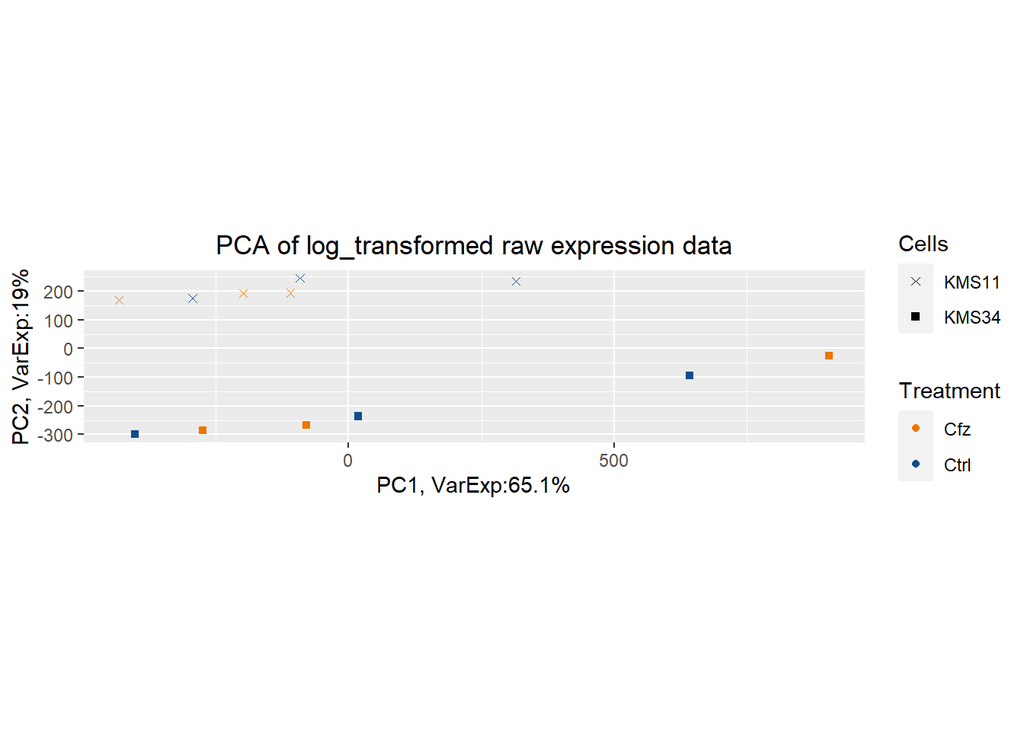

```r
# take log2 of expression and perform a PCA
exp_raw <- log2(exprs(celData))
PCA_raw <- prcomp(t(exp_raw), sacle. = FALSE)

percentVar <- round(100*PCA_raw$sdev^2/sum(PCA_raw$sdev^2),1)
sd_ratio <- sqrt(percentVar[2]/percentVar[1])

ggData <- data.frame(PC1 = PCA_raw$x[,1],
                     PC2 = PCA_raw$x[,2],
                     Cells = ph@data$CellLine,
                     Treatment = ph@data$Treatment)

ggplot(ggData, aes(PC1, PC2)) + geom_point(aes(shape = Cells, colour = Treatment))+
  ggtitle("PCA of log_transformed raw expression data") + xlab(paste0("PC1, VarExp:", percentVar[1], "%")) +
  ylab(paste0("PC2, VarExp:", percentVar[2], "%")) + theme(plot.title = element_text(hjust = 0.5)) +
  coord_fixed(ratio = sd_ratio) + scale_shape_manual(values = c(4,15)) + scale_color_manual(values = c("darkorange2", "dodgerblue4"))
```

```r
rm(exp_raw, PCA_raw, percentVar, sd_ratio, ggData)
```

As shown above, two cell types are separated by second principal component, which could be problematic for further analysis. To have a closer look at the quality we can draw a boxplot of log intensity of expressions.

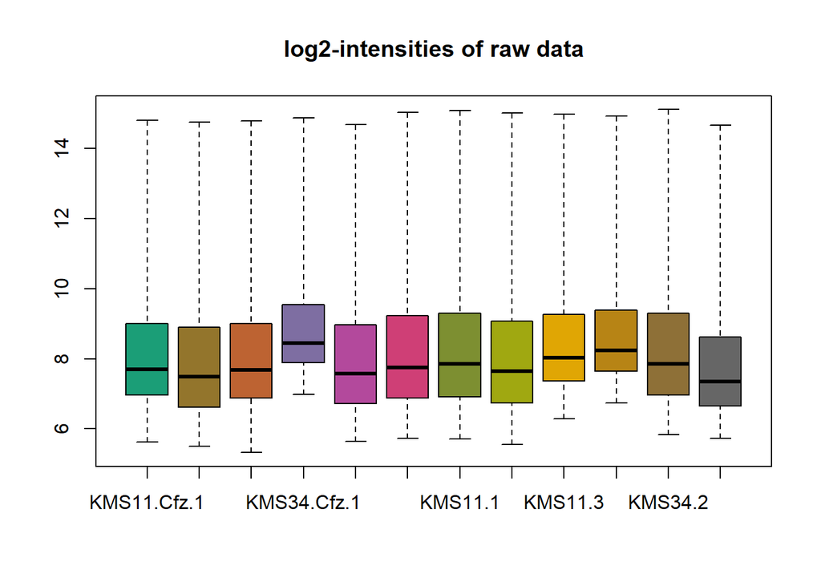

```r
set.seed(521)
oligo::boxplot(celData, target = "core", main = "log2-intensities of raw data")
```

The boxplot shows different median and scale of the boxes, meaning the need of normalization. Before normalization we perform another quality control test, called relative log expression (RLE).

```r
pData(celData)[,1] <- c("KMS.11.Cfz","KMS.11.Cfz","KMS.11.Cfz","KMS.34.Cfz","KMS.34.Cfz","KMS.34.Cfz", "KMS.11","KMS.11","KMS.11","KMS.34","KMS.34","KMS.34")
pData(celData)[,2] <- c("KMS11","KMS11","KMS11","KMS34","KMS34","KMS34", "KMS11","KMS11","KMS11","KMS34","KMS34","KMS34")
pData(celData)[,3] <- c("Cfz", "Cfz", "Cfz", "Cfz", "Cfz", "Cfz", "Ctrl", "Ctrl", "Ctrl", "Ctrl", "Ctrl", "Ctrl")
names(celData@phenoData@data) <- c("Groups", "Cells", "Treatments")

rleData <- rma(celData, normalize = FALSE) # without normalization to get only log2 values
```

```
## Background correcting
## Calculating Expression
```

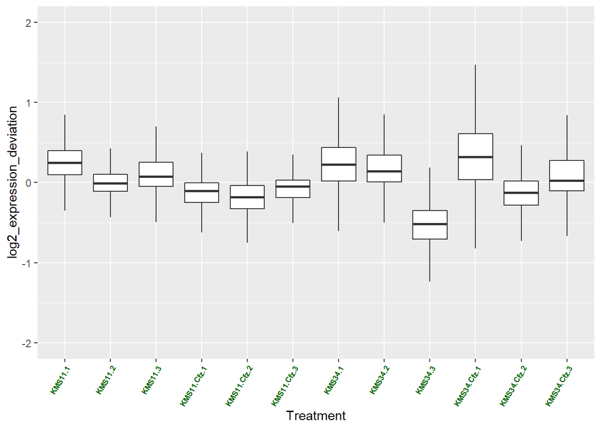

```r
# The RLE is performed by calculating the median log2 intensity of every transcript across all arrays.
row_medians <- Biobase::rowMedians(as.matrix(exprs(rleData)))

#We then substract this transcript median intensity from every transcript intensity via the sweep function.
RLE_Data <- sweep(exprs(rleData), 1, row_medians)
RLE_Data <- as.data.frame(RLE_Data)

Rle_Data_gathered <- gather(RLE_Data, Treatment, log2_expression_deviation)

ggplot(Rle_Data_gathered, aes(Treatment, log2_expression_deviation)) +
  geom_boxplot(outlier.shape = NA) + ylim(c(-2,2)) +
  theme(axis.text.x = element_text(colour = "darkgreen", angle = 60, size = 6.5, hjust = 1, face = "bold"))
```

```r
rm(RLE_Data, Rle_Data_gathered, rleData, row_medians)
```

The boxes with larger extension indicate high deviation from the median. The boxes shifted in y-direction indicate systematically high or lower expression, due to quality issues or batch effects.

## Normalization

Now we will apply RMA algorithm for background correction and normalization.

```r
eset_norm <- rma(celData)
```

```
## Background correcting
## Normalizing
## Calculating Expression
```

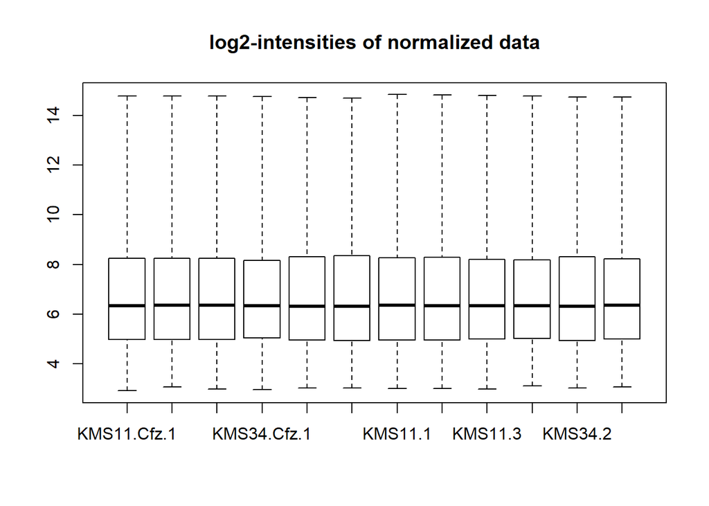

```r
set.seed(754)
oligo::boxplot(eset_norm, target = "core", main = "log2-intensities of normalized data")
```

The boxplot above shows that RMA algorithm has done a good job in normalizing the data. We can prove it by PCA plot.

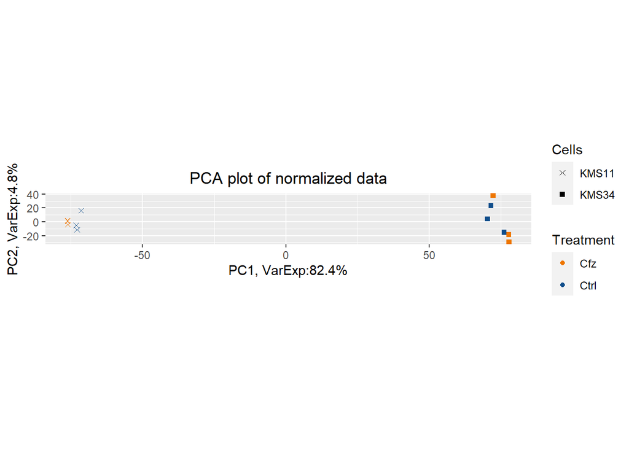

```r
norm_exp <- exprs(eset_norm)
PCA <- prcomp(t(norm_exp), scale. = F)
percentVar <- round(100*PCA$sdev^2/sum(PCA$sdev^2),1)
sd_ratio <- sqrt(percentVar[2]/percentVar[1])
ggData <- data.frame(PC1 = PCA$x[,1],
                     PC2 = PCA$x[,2],
                     Cells = pData(eset_norm)$Cells,
                     Treatment = pData(eset_norm)$Treatment)

ggplot(ggData, aes(PC1, PC2)) +
  geom_point(aes(shape = Cells, colour = Treatment)) +
  ggtitle("PCA plot of normalized data") +
  xlab(paste0("PC1, VarExp:", percentVar[1], "%")) +
  ylab(paste0("PC2, VarExp:", percentVar[2], "%")) +
  theme(plot.title = element_text(hjust = 0.5)) +
  coord_fixed(ratio = sd_ratio) +
  scale_shape_manual(values = c(4,15)) +
  scale_color_manual(values = c("darkorange2", "dodgerblue4"))
```

```r
rm(norm_exp, PCA, percentVar, sd_ratio, ggData)
```

After normalization, the cell types are separated by first principal component.

## Filtering

Next, we will exclude the lowly expressed genes. To this aim, we will calculate row-wise medians of gene expression intensity. Then we will set a cutoff to remove the defined expressions.

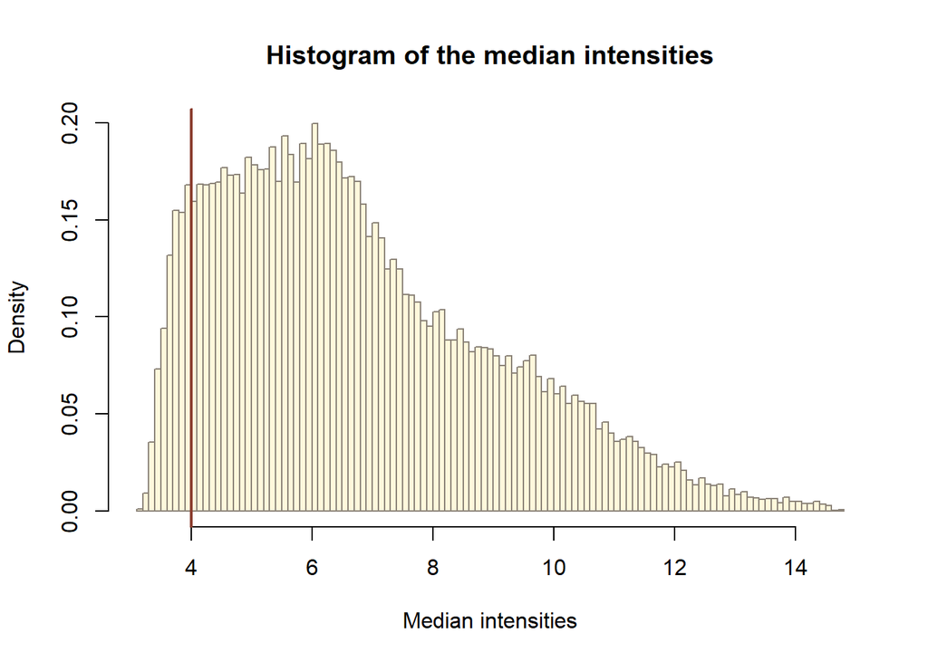

```r
eset_medians <- rowMedians(exprs(eset_norm))
hist(eset_medians, 100, col = "cornsilk1", freq = FALSE,
     main = "Histogram of the median intensities",
     border = "antiquewhite4", xlab = "Median intensities")
# set cutoff threshold left to the histogram peak
cut_thereshold <- 4
abline(v=cut_thereshold, col = "coral4", lwd = 2)
```

We can exlude the low medians, which are enriched on the left hand side of the histogram.

```r
idx_cut_threshold <- apply(exprs(eset_norm), 1, function(x){
  sum(x>cut_thereshold) >= 3}) # number of arrays where the median intesity passes the threshold is greater than the sample cutoff(we have 3 samples per replicate)

table(idx_cut_threshold) # 3437 arrays can be removed
```

```
## idx_cut_threshold
## FALSE  TRUE
##  3437 51238
```

```r
eset_norm_filtered <- subset(eset_norm, idx_cut_threshold)

rm(cut_thereshold, eset_medians, idx_cut_threshold)
```

To perform differntial expression analysis, we need first to add some more annotation information to featureData of our expression set.

```r
anno_eset <- AnnotationDbi::select(hgu133plus2.db, keys = (featureNames(eset_norm_filtered)),
                                   columns = c("SYMBOL", "GENENAME"),
                                   keytype = "PROBEID")
anno_eset <- subset(anno_eset, !is.na(SYMBOL)) # filterout probes that do not map to a gene
```

Many transcript identifiers are mapped to multiple gene symbols, which we are going to remove. First we filter the Probe Ids with multiple matches. Then we subset the expression set based on filtered probe IDs. We will also remove the corresponding IDs from annotation set. Finaly we will merge the expression set and annotation set to get a final set to work with.

```r
anno_grouped <- group_by(anno_eset, PROBEID)
anno_summarized <- summarize(anno_grouped, no_of_matches = n_distinct(SYMBOL))


anno_filtered <- filter(anno_summarized, no_of_matches > 1) # filter for PROBEIDs with multiple matches
head(anno_filtered)
```

```
## # A tibble: 6 x 2
##   PROBEID      no_of_matches
##   <chr>                <int>
## 1 1007_s_at                2
## 2 1294_at                  2
## 3 1552283_s_at             2
## 4 1552411_at               2
## 5 1552412_a_at             2
## 6 1552449_a_at             2
```

```r
nrow(anno_filtered) # 2157 PROBEID with multiple matches, difficult to decide which mapping is correct. Therefoe we exclude these clusters
```

```
## [1] 2157
```

```r
ids_to_exclude <- (featureNames(eset_norm_filtered) %in% anno_filtered$PROBEID)
table(ids_to_exclude)
```

```
## ids_to_exclude
## FALSE  TRUE
## 49081  2157
```

```r
# subset to final eset
eset_final <- subset(eset_norm_filtered, !ids_to_exclude)
validObject(eset_final)# TRUE
```

```
## [1] TRUE
```

```r
# we should also remove probe IDs from anno_eset
head(anno_eset)
```

```
##     PROBEID  SYMBOL                                     GENENAME
## 1 1007_s_at    DDR1  discoidin domain receptor tyrosine kinase 1
## 2 1007_s_at MIR4640                                microRNA 4640
## 3   1053_at    RFC2               replication factor C subunit 2
## 4    117_at   HSPA6 heat shock protein family A (Hsp70) member 6
## 5    121_at    PAX8                                 paired box 8
## 6 1255_g_at  GUCA1A               guanylate cyclase activator 1A
```

```r
# first we store feature data in eset_final, defining PROBEID column
fData(eset_final)$PROBEID <- rownames(fData(eset_final))

# left_join anno_eset
fData(eset_final) <- left_join(fData(eset_final), anno_eset)

# restore row names
rownames(fData(eset_final)) <- fData(eset_final)$PROBEID
validObject(eset_final)
```

```
## [1] TRUE
```

```r
rm(anno_eset, anno_filtered, anno_grouped, anno_summarized, eset_norm, eset_norm_filtered, ids_to_exclude)
```

## Differential Gene Expression

As we see in exprimental design, two cell lines have been treated with anti cancer drug. Therefor we should consider two factors affecting the outcomes: 1. Cell types: KMS11 and KMS34 2. Treatment: control vs. Carfilzomib

One can do a joint model of differential expression analysis, but the result could be affected by two factors. As we could see before the main difference in expression pattern is coming from the type of the cells.

We will create two design matrices, one for each cell line. Then we will explore the differential gene expression separately for each cell line.

```r
Groups <- as.character(pData(eset_final)$Groups)
Cells <- as.character(pData(eset_final)$Cells)
Treatment <- as.character(pData(eset_final)$Treatment)

# according to the original paper we look for the changes in transcription occur between treatments. we create two designe matrices one for each cell line

i_11 <- Groups[Cells == "KMS11"]
design_eset_11 <- model.matrix(~ 0 + Treatment[Cells == "KMS11"] + i_11)
colnames(design_eset_11)[1:2] <- c("Cfz", "Ctrl")
rownames(design_eset_11) <- i_11



i_34 <-  Groups[Cells == "KMS34"]
design_eset_34 <- model.matrix(~ 0 + Treatment[Cells == "KMS34"] + i_34)
colnames(design_eset_34)[1:2] <- c("Cfz", "Ctrl")
rownames(design_eset_34) <- i_34




contrast_matrix_11 <- makeContrasts(Cfz-Ctrl, levels = design_eset_11)
eset_fit_11 <- eBayes(contrasts.fit(lmFit(eset_final[,Cells =="KMS11"],
                                          design = design_eset_11),
                                    contrast_matrix_11))
```

```
## Coefficients not estimable: i_11KMS.11.Cfz
```

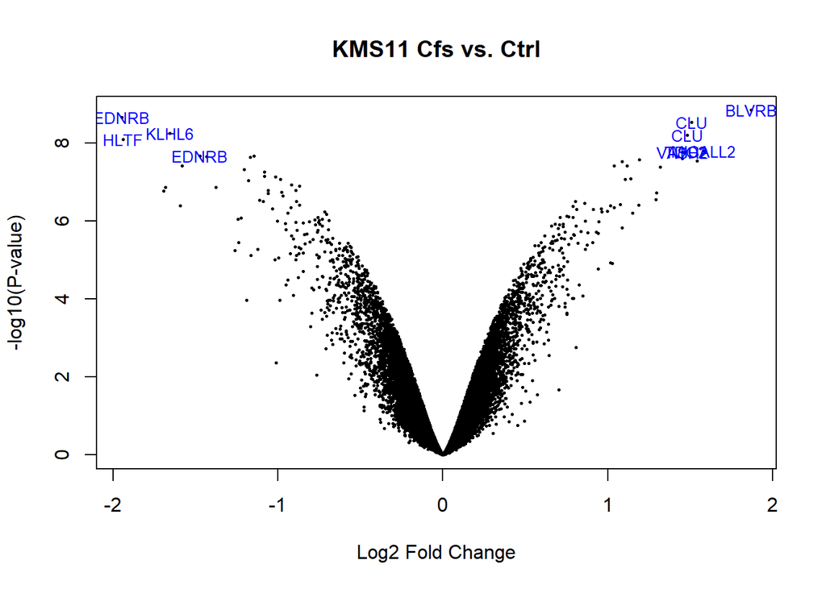

```r
volcano_names <- ifelse(abs(eset_fit_11$coefficients)>=1,
                        eset_fit_11$genes$SYMBOL, NA)
volcanoplot(eset_fit_11, style = "p-value", highlight = 10, names = volcano_names, main = "KMS11 Cfs vs. Ctrl",
            xlab = "Log2 Fold Change", ylab = NULL, pch = 16, cex = 0.35)
```

```r
contrast_matrix_34 <- makeContrasts(Cfz-Ctrl, levels = design_eset_34)
eset_fit_34 <- eBayes(contrasts.fit(lmFit(eset_final[,Cells =="KMS34"],
                                          design = design_eset_34),
                                    contrast_matrix_34))
```

```
## Coefficients not estimable: i_34KMS.34.Cfz
```

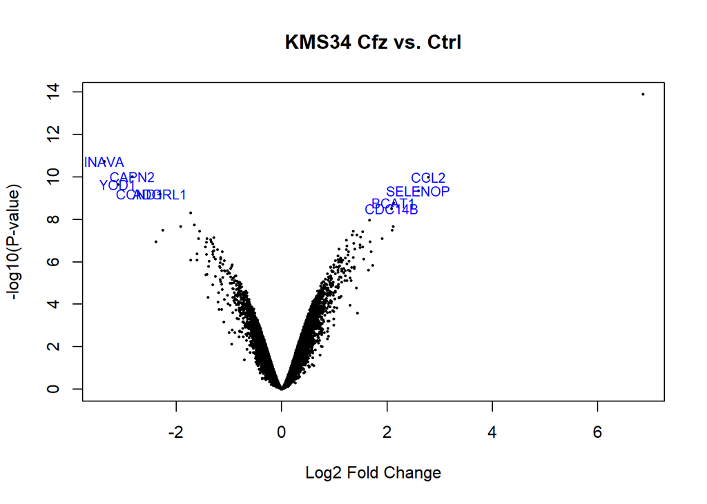

```r
volcano_names <- ifelse(abs(eset_fit_34$coefficients)>=1,
                        eset_fit_34$genes$SYMBOL, NA)
volcanoplot(eset_fit_34, style = "p-value", highlight = 10, names = volcano_names,main = "KMS34 Cfz vs. Ctrl",
            xlab = "Log2 Fold Change", ylab = NULL, pch = 16, cex = 0.35)
```

```r
rm(design_eset_11, design_eset_34, contrast_matrix_11, contrast_matrix_34, volcano_names)
```

we will set another cutoff, this time for genes with FDR < 5%, and select the top 50 genes. Then we will look for the ones that are listed in both cell lines.

```r
table_11 <- topTable(eset_fit_11, number = Inf)
table_11 <- table_11[order(table_11$adj.P.Val),]

selected_11 <- subset(table_11, adj.P.Val < 0.05)$PROBEID
eset_11 <- eset_final[selected_11,]
table_11[1:20,]
```

```
##                 PROBEID   SYMBOL                                       GENENAME
## 202201_at     202201_at    BLVRB                         biliverdin reductase B
## 204273_at     204273_at    EDNRB                     endothelin receptor type B
## 208792_s_at 208792_s_at      CLU                                      clusterin
## 228167_at     228167_at    KLHL6                     kelch like family member 6
## 208791_at     208791_at      CLU                                      clusterin
## 202983_at     202983_at     HLTF             helicase like transcription factor
## 219332_at     219332_at  MICALL2                                   MICAL like 2
## 205943_at     205943_at     TDO2                     tryptophan 2,3-dioxygenase
## 235343_at     235343_at    VASH2                                    vasohibin 2
## 204271_s_at 204271_s_at    EDNRB                     endothelin receptor type B
## 215071_s_at 215071_s_at    H2AC6                        H2A clustered histone 6
## 213478_at     213478_at     KAZN         kazrin, periplakin interacting protein
## 213725_x_at 213725_x_at    XYLT1                           xylosyltransferase 1
## 207469_s_at 207469_s_at      PIR                                          pirin
## 205348_s_at 205348_s_at  DYNC1I1      dynein cytoplasmic 1 intermediate chain 1
## 244407_at     244407_at  CYP39A1 cytochrome P450 family 39 subfamily A member 1
## 226884_at     226884_at    LRRN1                 leucine rich repeat neuronal 1
## 206435_at     206435_at B4GALNT1  beta-1,4-N-acetyl-galactosaminyltransferase 1
## 231202_at     231202_at  ALDH1L2      aldehyde dehydrogenase 1 family member L2
## 214453_s_at 214453_s_at    IFI44                  interferon induced protein 44
##                 logFC   AveExpr         t      P.Value    adj.P.Val         B
## 202201_at    1.869936  8.807137  26.95125 1.459023e-09 4.897298e-05 11.102438
## 204273_at   -1.948802  7.130911 -25.60933 2.245892e-09 4.897298e-05 10.860155
## 208792_s_at  1.509581 10.262785  24.75196 2.993397e-09 4.897298e-05 10.692061
## 228167_at   -1.657025  7.902680 -22.92630 5.708484e-09 6.138967e-05 10.294928
## 208791_at    1.482413 11.109431  22.67903 6.253914e-09 6.138967e-05 10.236636
## 202983_at   -1.941043  6.632884 -21.95384 8.219491e-09 6.723681e-05 10.058900
## 219332_at    1.582225  7.777727  20.20826 1.647661e-08 8.722768e-05  9.585644
## 205943_at    1.474411  9.779951  20.11456 1.713108e-08 8.722768e-05  9.558261
## 235343_at    1.452338  8.611744  20.09117 1.729889e-08 8.722768e-05  9.551393
## 204271_s_at -1.475680  8.473025 -19.58051 2.146196e-08 8.722768e-05  9.398023
## 215071_s_at -1.146725  9.794489 -19.56751 2.158170e-08 8.722768e-05  9.394030
## 213478_at   -1.435260  7.785572 -19.46759 2.252658e-08 8.722768e-05  9.363209
## 213725_x_at -1.167839  9.318152 -19.40882 2.310384e-08 8.722768e-05  9.344958
## 207469_s_at  1.452366  9.864046  19.18951 2.540833e-08 8.763801e-05  9.276042
## 205348_s_at  1.191151  8.806821  19.06623 2.681551e-08 8.763801e-05  9.236735
## 244407_at    1.542139  6.609986  18.92232 2.856927e-08 8.763801e-05  9.190322
## 226884_at    1.087630  8.957578  18.78237 3.039815e-08 8.776302e-05  9.144636
## 206435_at    1.037522  8.035055  18.26359 3.840997e-08 9.570303e-05  8.970401
## 231202_at   -1.581674  5.128670 -18.24631 3.871466e-08 9.570303e-05  8.964462
## 214453_s_at  1.116407  7.436343  18.23038 3.899800e-08 9.570303e-05  8.958977
```

```r
table_34 <- topTable(eset_fit_34, number = Inf)
table_34 <- table_34[order(table_34$adj.P.Val),]

selected_34 <- subset(table_34, adj.P.Val < 0.05)$PROBEID
eset_34 <- eset_final[selected_34,]
table_34[1:20,]
```

```
##                   PROBEID   SYMBOL                                  GENENAME
## 1570561_at     1570561_at     <NA>                                      <NA>
## 219010_at       219010_at    INAVA                 innate immunity activator
## 208683_at       208683_at    CAPN2                                 calpain 2
## 216598_s_at   216598_s_at     CCL2              C-C motif chemokine ligand 2
## 227309_at       227309_at     YOD1                       YOD1 deubiquitinase
## 201427_s_at   201427_s_at  SELENOP                           selenoprotein P
## 47560_at         47560_at   ADGRL1    adhesion G protein-coupled receptor L1
## 208712_at       208712_at    CCND1                                 cyclin D1
## 226517_at       226517_at    BCAT1  branched chain amino acid transaminase 1
## 221556_at       221556_at   CDC14B                   cell division cycle 14B
## 204693_at       204693_at CDC42EP1                  CDC42 effector protein 1
## 213385_at       213385_at     CHN2                                chimerin 2
## 203488_at       203488_at   ADGRL1    adhesion G protein-coupled receptor L1
## 205945_at       205945_at     IL6R                    interleukin 6 receptor
## 209993_at       209993_at    ABCB1 ATP binding cassette subfamily B member 1
## 219014_at       219014_at    PLAC8                     placenta associated 8
## 241902_at       241902_at      MKX                           mohawk homeobox
## 214023_x_at   214023_x_at   TUBB2B                 tubulin beta 2B class IIb
## 1559633_a_at 1559633_a_at    CHRM3         cholinergic receptor muscarinic 3
## 213317_at       213317_at    CLIC5          chloride intracellular channel 5
##                  logFC   AveExpr         t      P.Value    adj.P.Val         B
## 1570561_at    6.853069  7.073665  60.45575 1.265977e-14 6.213544e-10 15.634700
## 219010_at    -3.367840  7.955391 -30.03019 1.798832e-11 4.414424e-07 13.655987
## 208683_at    -2.836567  7.966765 -25.49045 9.737421e-11 1.217429e-06 12.863409
## 216598_s_at   2.779253  7.634725  25.44399 9.921793e-11 1.217429e-06 12.853781
## 227309_at    -3.111960  5.469877 -23.48560 2.258282e-10 2.216774e-06 12.413589
## 201427_s_at   2.593112 10.211654  22.00484 4.400524e-10 3.599702e-06 12.030629
## 47560_at     -2.313644  8.214669 -21.33253 6.043591e-10 3.788238e-06 11.840398
## 208712_at    -2.700215  6.304828 -21.28778 6.174672e-10 3.788238e-06 11.827345
## 226517_at     2.123438  5.946158  19.32664 1.654177e-09 9.020961e-06 11.202607
## 221556_at     2.078258  6.701036  18.16822 3.099017e-09 1.521029e-05 10.779298
## 204693_at    -1.732164  6.606430 -17.36845 4.888880e-09 2.181374e-05 10.459933
## 213385_at     1.660382  7.477734  16.09525 1.053795e-08 4.310111e-05  9.899924
## 203488_at    -1.663000  7.510079 -15.30861 1.743102e-08 6.581015e-05  9.518583
## 205945_at    -1.918118  9.312174 -15.05377 2.062329e-08 6.839252e-05  9.388710
## 209993_at     2.111613  7.585363  15.03361 2.090193e-08 6.839252e-05  9.378294
## 219014_at     2.096047  7.667331  14.45948 3.084540e-08 8.981279e-05  9.072991
## 241902_at    -2.263120  7.726152 -14.44719 3.110812e-08 8.981279e-05  9.066267
## 214023_x_at   1.357140  9.719986  14.26270 3.536123e-08 9.174785e-05  8.964322
## 1559633_a_at -1.557410  5.070559 -14.25641 3.551698e-08 9.174785e-05  8.960814
## 213317_at     1.531224  5.865288  14.14117 3.850794e-08 9.450041e-05  8.896137
```

```r
shared_genes <- selected_11[c(which(selected_11 %in% selected_34))]
shared_DE <-AnnotationDbi::select(hgu133plus2.db, keys = (shared_genes),
                      columns = c("SYMBOL", "GENENAME"),
                      keytype = "PROBEID")
dim(shared_DE)
```

```
## [1] 189   3
```

```r
shared_DE[1:10,]
```

```
##        PROBEID    SYMBOL                                            GENENAME
## 1    213478_at      KAZN              kazrin, periplakin interacting protein
## 2    205081_at     CRIP1                             cysteine rich protein 1
## 3     47069_at      PRR5                                      proline rich 5
## 4    209398_at      H1-2                 H1.2 linker histone, cluster member
## 5  210644_s_at     LAIR1 leukocyte associated immunoglobulin like receptor 1
## 6    222838_at    SLAMF7                                SLAM family member 7
## 7  219168_s_at      PRR5                                      proline rich 5
## 8  208869_s_at GABARAPL1      GABA type A receptor associated protein like 1
## 9    208712_at     CCND1                                           cyclin D1
## 10   226225_at       MCC              MCC regulator of WNT signaling pathway
```

189 genes are differentially expressed under Carfilzomib treatmnet (aquired resistance) in both cell lines. Top 10 of them are printed above.

Now, we will draw a heatmap for differentially expressed gene in each set.

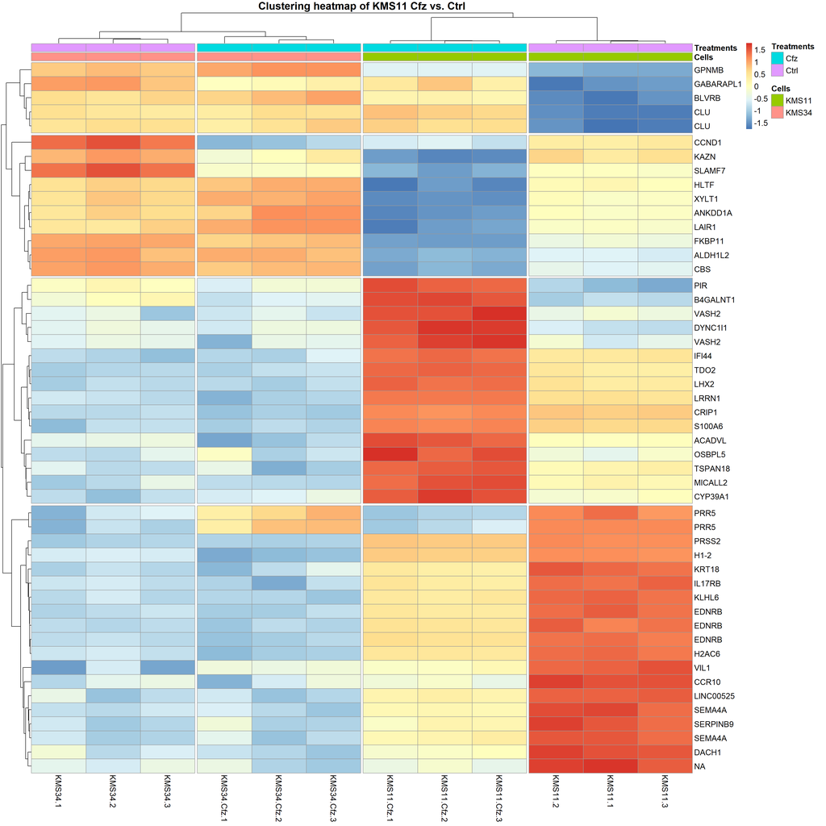

```r
heat_table <- table_11[1:50,]
heat_ID <- heat_table$PROBEID
heat_set <- eset_final[heat_ID,]
exprs_11 <- exprs(heat_set)
row.names(exprs_11) <- heat_table$SYMBOL


pheatmap(exprs_11,
         annotation_col = heat_set@phenoData@data[,c("Cells", "Treatments")],
         scale = "row",
         cutree_rows = 4, cutree_cols = 4, fontsize = 14,
         main = "Clustering heatmap of KMS11 Cfz vs. Ctrl")
```

```r
rm(exprs_11)
```

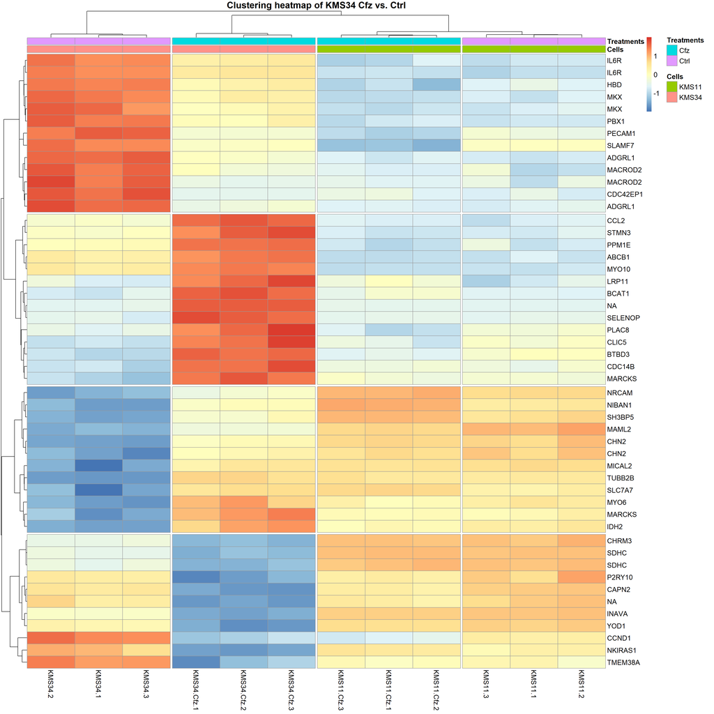

```r
heat_table <- table_34[1:50,]
heat_ID <- heat_table$PROBEID
heat_set <- eset_final[heat_ID,]
exprs_34 <- exprs(heat_set)
row.names(exprs_34) <- heat_table$SYMBOL


pheatmap(exprs_34,
         annotation_col = heat_set@phenoData@data[,c("Cells", "Treatments")],
         scale = "row",
         cutree_rows = 4, cutree_cols = 4, fontsize = 14,
         main = "Clustering heatmap of KMS34 Cfz vs. Ctrl")
```

```r
rm(heat_table, heat_ID, heat_set, exprs_34)
```

## GO Enrichment Analysis

Now we can do some enrichment analysis of DE genes, base on gene ontology. First we find a set of background genes which are similar in expression to DE genes, and look at their distribution to avoid the biased background.

```r
back_genes_id11 <- genefinder(eset_final, as.character(selected_11), method = "manhattan", scale = "none")
back_genes_id11 <- sapply(back_genes_id11, function(x)x$indices)

back_genes_id34 <- genefinder(eset_final, as.character(selected_34), method = "manhattan", scale = "none")
back_genes_id34 <- sapply(back_genes_id34, function(x)x$indices)


back_genes11 <- featureNames(eset_final)[back_genes_id11]
back_genes11 <- setdiff(back_genes11, selected_11)
intersect(back_genes11, selected_11)
```

```
## character(0)
```

```r
length(back_genes11)
```

```
## [1] 17045
```

```r
back_genes34 <- featureNames(eset_final)[back_genes_id34]
back_genes34 <- setdiff(back_genes34, selected_34)
intersect(back_genes34, selected_34)
```

```
## character(0)
```

```r
length(back_genes34)
```

```
## [1] 11151
```

The intersect = 0 confirmes that the back_genes are not included in selected DE genes. To check whether the background genes are not biased for the gene enrichment analysis, we will creat a multidensity plot, where the mean expression is plotted on the x-axis, and check for the similarity of the distribution of back-genes and fore-genes.

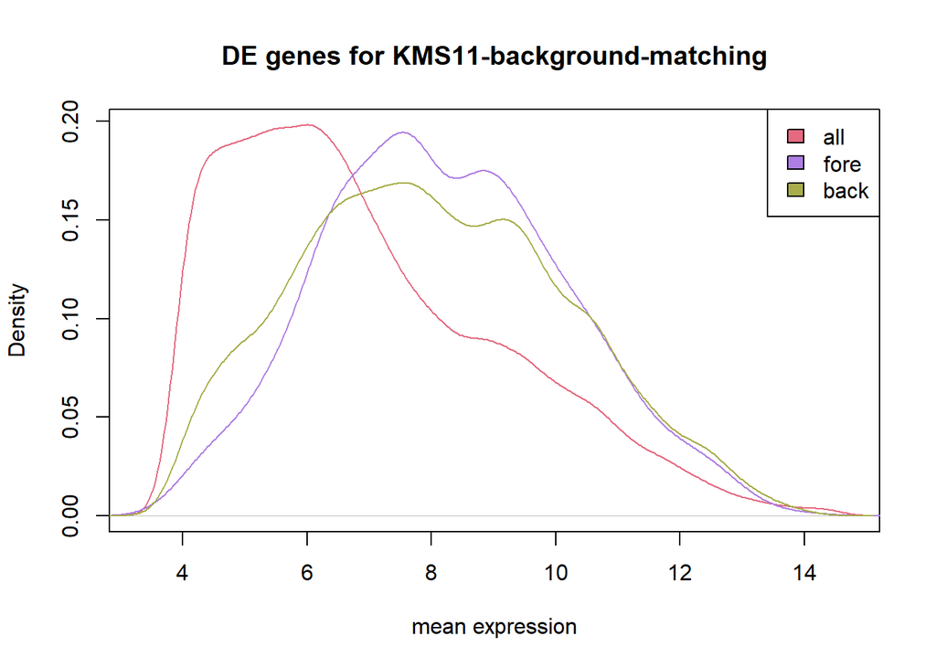

```r
multidensity(list(
  all = table_11[,"AveExpr"],
  fore = table_11[selected_11, "AveExpr"],
  back = table_11[rownames(table_11) %in% back_genes11, "AveExpr"]),
  col = c("#e46981", "#ae7ee2", "#a7ad4a"),
  xlab = "mean expression",
  main = "DE genes for KMS11-background-matching")
```

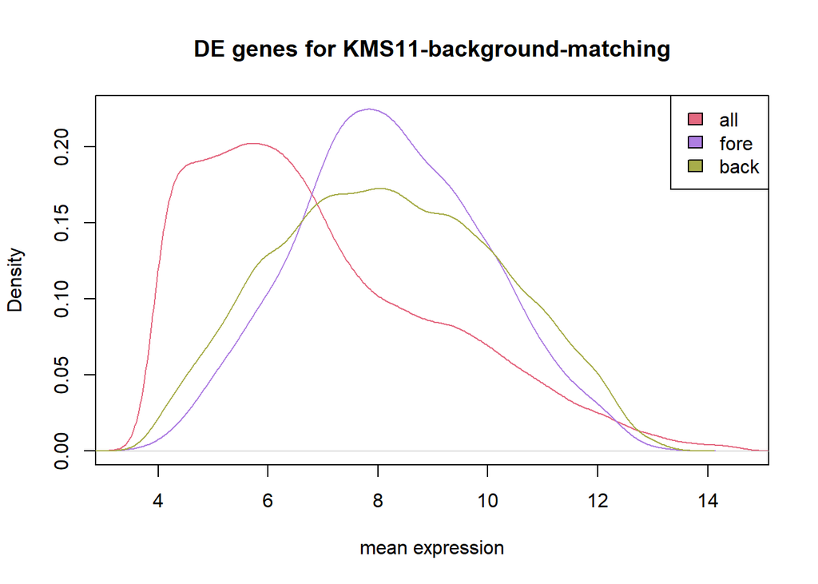

```r
multidensity(list(
  all = table_34[,"AveExpr"],
  fore = table_34[selected_34, "AveExpr"],
  back = table_34[rownames(table_34) %in% back_genes34, "AveExpr"]),
  col = c("#e46981", "#ae7ee2", "#a7ad4a"),
  xlab = "mean expression",
  main = "DE genes for KMS11-background-matching")
```

The distribution of bak and fore-genes are similar in both sets. Now we can perform GO enrichment analysis.

```r
gene_ID11 <- rownames(table_11)
in_universe <- gene_ID11 %in% c(selected_11, back_genes11)
in_selection <- gene_ID11 %in% selected_11

all_genes11 <- in_selection[in_universe]
all_genes11 <- factor(as.integer(in_selection[in_universe]))
names(all_genes11) <- gene_ID11[in_universe]



gene_ID34 <- rownames(table_34)
in_universe <- gene_ID34 %in% c(selected_34, back_genes34)
in_selection <- gene_ID34 %in% selected_34

all_genes34 <- in_selection[in_universe]
all_genes34 <- factor(as.integer(in_selection[in_universe]))
names(all_genes34) <- gene_ID34[in_universe]

## initialize topGO data set
top_GO_data_11 <- new("topGOdata", ontology = "BP", allGenes = all_genes11,
                      nodeSize = 10, annot = annFUN.db, affyLib = "hgu133plus2.db") # nodeSize=10 specifies a minimum size of GO category, categories with less than 10 genes are not included


top_GO_data_34 <- new("topGOdata", ontology = "BP", allGenes = all_genes34,
                      nodeSize = 10, annot = annFUN.db, affyLib = "hgu133plus2.db")


### testing with Fisher classic and elim algorithm
result11_topGO_elim <- runTest(top_GO_data_11, algorithm = "elim", statistic = "Fisher")
result11_topGO_classic <- runTest(top_GO_data_11, algorithm = "classic", statistic = "Fisher")



result34_topGO_elim <- runTest(top_GO_data_34, algorithm = "elim", statistic = "Fisher")
result34_topGO_classic <- runTest(top_GO_data_34, algorithm = "classic", statistic = "Fisher")

res_top_GO_11 <- GenTable(top_GO_data_11, Fisher.elim = result11_topGO_elim, Fisher.classic = result11_topGO_classic,
                          orderBy = "Fisher.elim", topNodes = 20)
genes_top_GO_11 <- printGenes(top_GO_data_11, whichTerms = res_top_GO_11$GO.ID, chip = "hgu133plus2.db", geneCutOff = 1000)

res_top_GO_11$sig_genes <- sapply(genes_top_GO_11, function(x){
  str_c(paste0(x[x$"raw p-value" == 2, "Symbol.id"], ";"), collapse = "")
})


res_top_GO_34 <- GenTable(top_GO_data_34, Fisher.elim = result34_topGO_elim, Fisher.classic = result34_topGO_classic,
                          orderBy = "Fisher.elim", topNodes = 20)
genes_top_GO_34 <- printGenes(top_GO_data_34, whichTerms = res_top_GO_34$GO.ID, chip = "hgu133plus2.db", geneCutOff = 1000)

res_top_GO_34$sig_genes <- sapply(genes_top_GO_34, function(x){
  str_c(paste0(x[x$"raw p-value" == 2, "Symbol.id"], ";"), collapse = "")
})
```

Now we can look at top terms of GO analysis

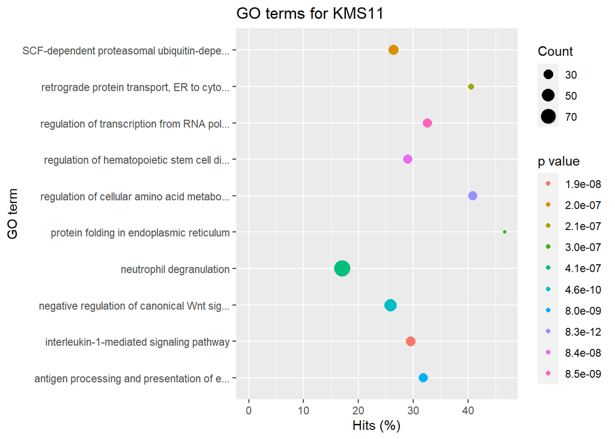

```r
res_top_GO_11 %>%
     top_n(10, wt=1/as.numeric(Fisher.elim)) %>%
     mutate(hitsPerc=Significant*100/Annotated) %>%
     ggplot(aes(x=hitsPerc,
                y=Term,
                colour=Fisher.elim,
                size=Significant)) +
     geom_point() +
     expand_limits(x=0) +
     labs(x="Hits (%)", y="GO term", colour="p value", size="Count") + ggtitle("GO terms for KMS11")
```

In KMS11, regulation of cellular amino acid and negative regulation of canonical Wnt signaling are at top.

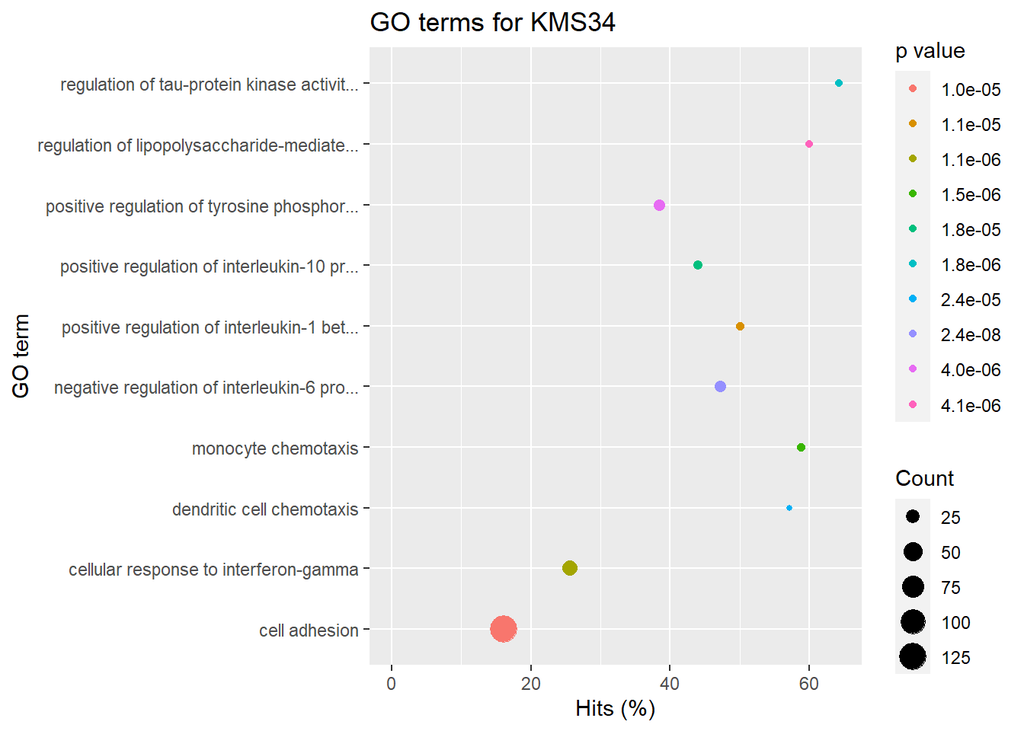

```r
res_top_GO_34 %>%
     top_n(10, wt=1/as.numeric(Fisher.elim)) %>%
     mutate(hitsPerc=Significant*100/Annotated) %>%
     ggplot(aes(x=hitsPerc,
                y=Term,
                colour=Fisher.elim,
                size=Significant)) +
     geom_point() +
     expand_limits(x=0) +
     labs(x="Hits (%)", y="GO term", colour="p value", size="Count") + ggtitle("GO terms for KMS34")
```

In KMS34, negative regulation of IL6 and regulation of cellular response to IF gamma are at top.

## Pathway enrichment analysis using reactom

We will also test the enrichment of specific pathways using Reactom pathway database. To do that we need first to convert the Probe IDs ti ENTREZ identifiers. Then a hypergeometric distribution test will be applyed, which is the same as Fisher Classic test that we performed above by topGO.

```r
entrez_ids_11 <- mapIds(hgu133plus2.db, keys = rownames(table_11), keytype = "PROBEID", column = "ENTREZID")

reactom_enrich_11 <- enrichPathway(gene = entrez_ids_11[selected_11],
                                   universe = entrez_ids_11[c(selected_11, back_genes11)],
                                   organism = "human",
                                   pvalueCutoff = 0.05, qvalueCutoff = 0.9, readable = TRUE)

reactom_enrich_11@result$Description <- paste0(str_sub(reactom_enrich_11@result$Description, 1, 30), "...")


entrez_ids_34 <- mapIds(hgu133plus2.db, keys = rownames(table_34), keytype = "PROBEID", column = "ENTREZID")

reactom_enrich_34 <- enrichPathway(gene = entrez_ids_34[selected_34],
                                   universe = entrez_ids_34[c(selected_34, back_genes34)],
                                   organism = "human",
                                   pvalueCutoff = 0.05, qvalueCutoff = 0.9, readable = TRUE)

reactom_enrich_34@result$Description <- paste0(str_sub(reactom_enrich_34@result$Description, 1, 30), "...")

#head(as.data.frame(reactom_enrich_11))[1:6]
#head(as.data.frame(reactom_enrich_34))[1:6]
```

Here we see the pathways related to the GO terms that we performed before.

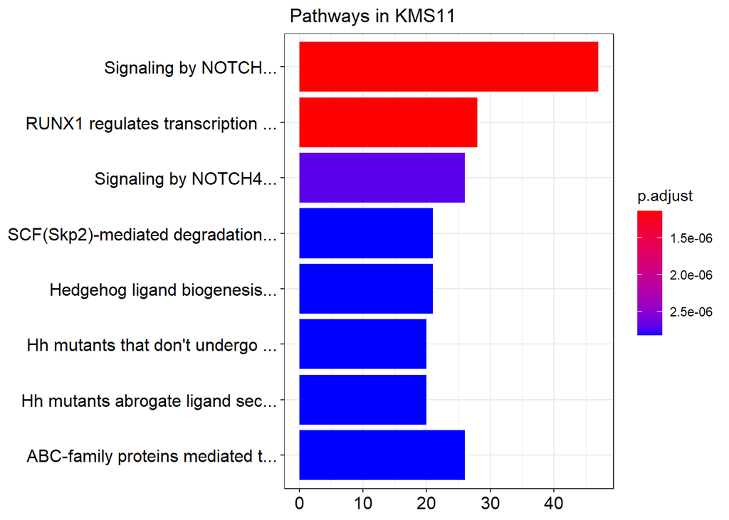

```r
barplot(reactom_enrich_11, title = " Pathways in KMS11")
```

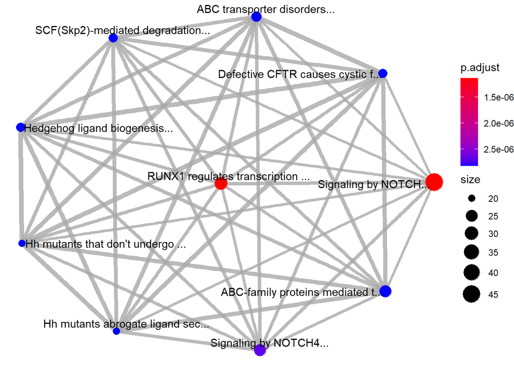

```r
emapplot(reactom_enrich_11, showCategory = 10)
```

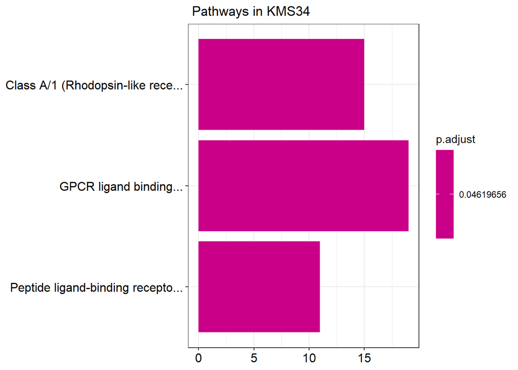

```r
barplot(reactom_enrich_34, title = " Pathways in KMS34")
```

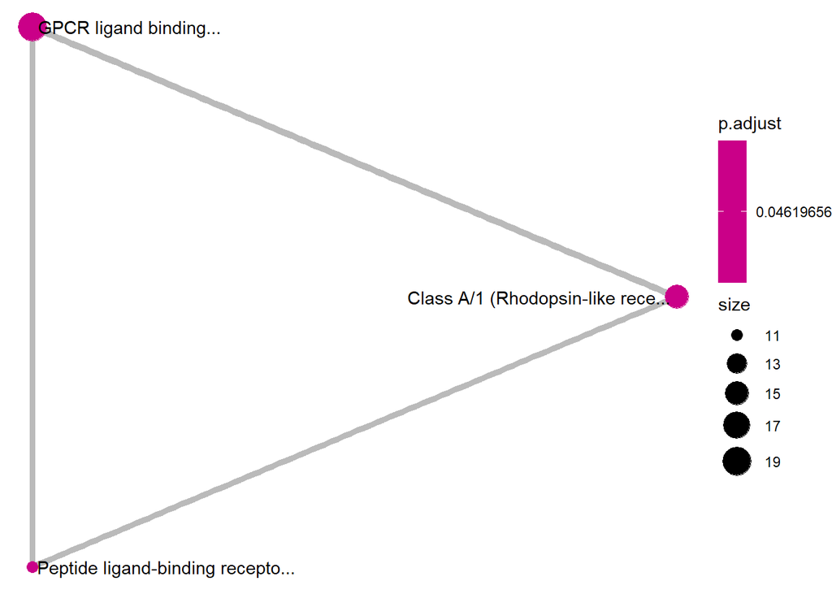

```r
emapplot(reactom_enrich_34, showCategory = 10)
```

## Conclusion

Here we analyzed the microarray data, that have been published by Riz I, et al on Oncotarget (PMID: 26109433). We didn’t aim to compare the results to the original paper. The important point here was to mention that the data is constructed of two main factors, the cell lines and treatment. Thus the analysis strategy is important, when we are going to define the contrasts for differential gene expression analysis. One can do a joint contrast, but the result might not be trustable. We could see clearly that the two cell lines behave differently in response to the anti cancer drug. Their expression profile, as well as activated pathways are different.

## Session Information

```r
gc()
```

```
##            used  (Mb) gc trigger (Mb)  max used (Mb)
## Ncells 13647550 728.9   24583814 1313  24583814 1313
## Vcells 42809763 326.7  140505987 1072 140505758 1072
```

```r
length(getLoadedDLLs())
```

```
## [1] 99
```